# Enfoque Estadistico del Aprendizaje - Trabajo Final - Regresion Bayesiana

## Referencias:

- [Making Predictions from Stan models in R](https://medium.com/@alex.pavlakis/making-predictions-from-stan-models-in-r-3e349dfac1ed)
- [How to represent a categorical predictor rstan?](https://stackoverflow.com/questions/29183577/how-to-represent-a-categorical-predictor-rstan)

```r
set.seed(42)
options(mc.cores = 24)
```

# Librerias

A continuación se realiza la llamada de las librerías a ser utilizadas a lo largo del Trabajo Practico:

```r
# install.packages(pacman)
# install.packages("https://cran.r-project.org/src/contrib/rstan_2.21.2.tar.gz",repos = NULL,type="source")
# sudo apt-get install libglpk-dev
```

```r
library(pacman)
p_load(tidyverse, tidymodels, rsample, rstan, shinystan, rstanarm, devtools)
p_load_gh('adrianmarino/commons')

import('../src/dataset.R')
```

```
## [1] "-> '../src/dataset.R' script loadded successfuly!"
```

```r
import('../src/plot.R')
```

```
## [1] "-> '../src/plot.R' script loadded successfuly!"
```

```r
import('../src/model.R')
```

```
## [1] "-> './bayesian_regression_predictor.R' script loadded successfuly!"
## [1] "-> '../src/model.R' script loadded successfuly!"
```

# Dataset y Analisis Exploratorio

## 1. Lectura del dataset

[Palmer Penguins](https://github.com/rfordatascience/tidytuesday/blob/master/data/2020/2020-07-28/readme.md)

```r
# Lectura
dataset <- load_dataset() %>%
  mutate_if(is.character, as.factor)

# Resumen
dataset %>% glimpse()
```

```
## Rows: 344
## Columns: 8
## $ species           <fct> Adelie, Adelie, Adelie, Adelie, Adelie, Adelie, Adel…
## $ island            <fct> Torgersen, Torgersen, Torgersen, Torgersen, Torgerse…
## $ bill_length_mm    <dbl> 39.1, 39.5, 40.3, NA, 36.7, 39.3, 38.9, 39.2, 34.1, …
## $ bill_depth_mm     <dbl> 18.7, 17.4, 18.0, NA, 19.3, 20.6, 17.8, 19.6, 18.1, …
## $ flipper_length_mm <dbl> 181, 186, 195, NA, 193, 190, 181, 195, 193, 190, 186…
## $ body_mass_g       <dbl> 3750, 3800, 3250, NA, 3450, 3650, 3625, 4675, 3475, …
## $ sex               <fct> male, female, female, NA, female, male, female, male…
## $ year              <dbl> 2007, 2007, 2007, 2007, 2007, 2007, 2007, 2007, 2007…
```

```r
show_values(dataset %>% select_if(negate(is.numeric)))
```

```
## _____________
## species     n
## =============
## Adelie    152
## Chinstrap  68
## Gentoo    124
## ¯¯¯¯¯¯¯¯¯¯¯¯¯
## _____________
## island      n
## =============
## Biscoe    168
## Dream     124
## Torgersen  52
## ¯¯¯¯¯¯¯¯¯¯¯¯¯
## __________
## sex      n
## ==========
## female 165
## male   168
## NA      11
## ¯¯¯¯¯¯¯¯¯¯
```

## 2. Variables

Se enumeran y describen breve-mente cada variable que forma parte del dataset:

Varaibles Numéricas: * bill_length_mm * bill_depth_mm * flipper_length_mm * body_mass_g * year

Variables Categóricas: * species * sex * island

## 3. Conteo de NA

```r
missings_summary(dataset)
```

| Variable | Nª Categorias | Nª Faltantes | % Faltantes |
| --- | --- | --- | --- |
| sex | 3 | 11 | 3.20 |
| flipper_length_mm | 56 | 2 | 0.58 |
| bill_depth_mm | 81 | 2 | 0.58 |
| body_mass_g | 95 | 2 | 0.58 |
| bill_length_mm | 165 | 2 | 0.58 |
| island | 3 | 0 | 0.00 |
| species | 3 | 0 | 0.00 |
| year | 3 | 0 | 0.00 |

## 4. Varibles numericas

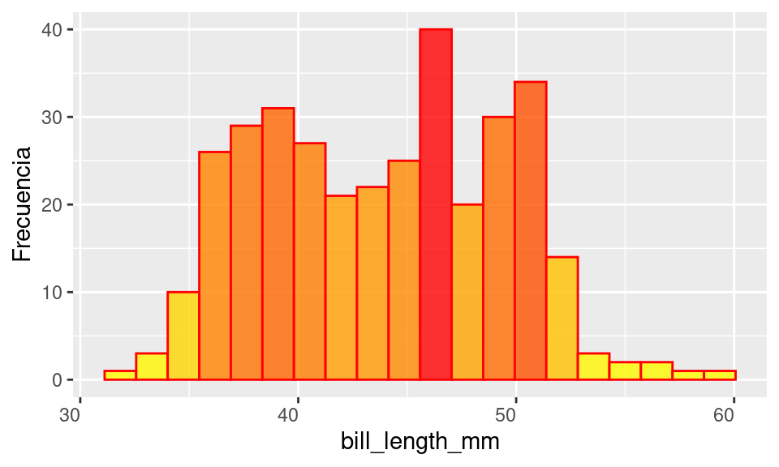

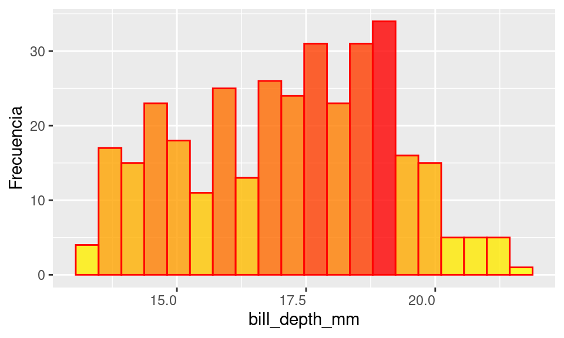

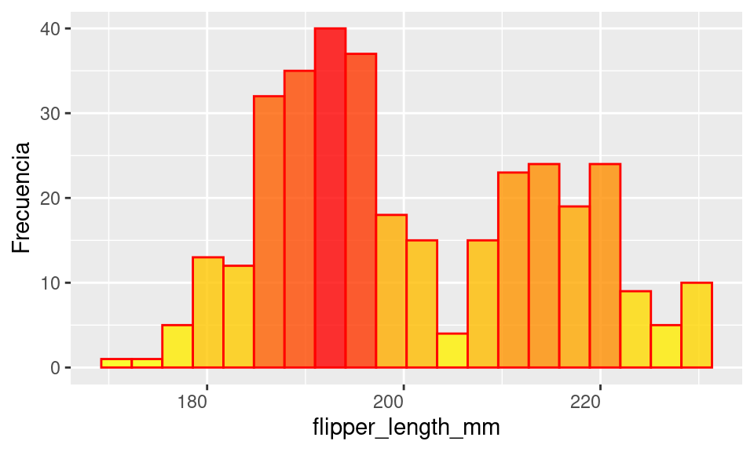

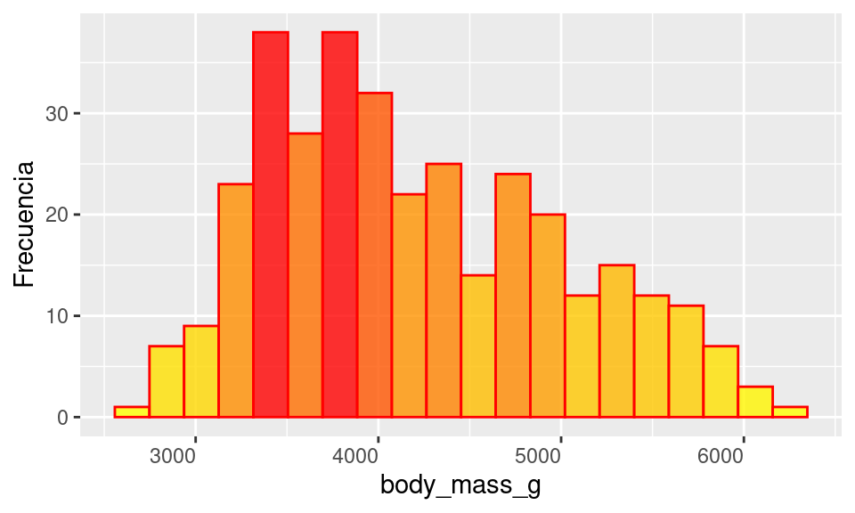

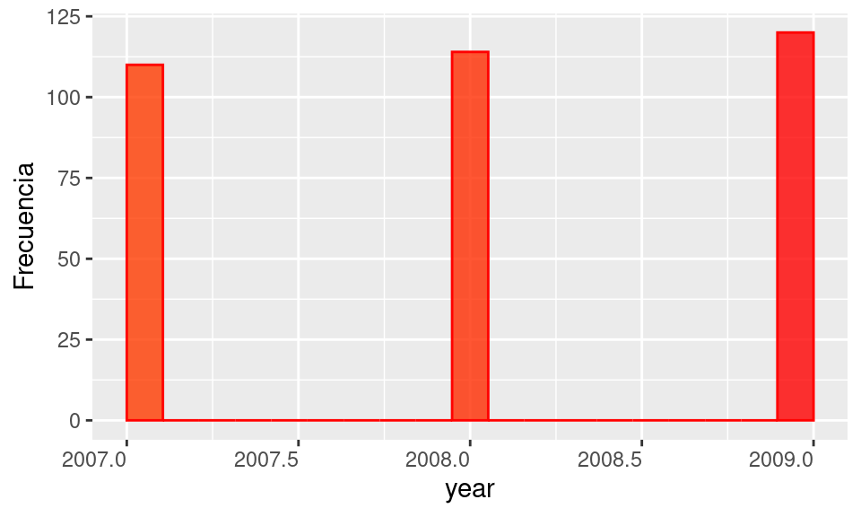

```r
hist_plots(dataset)
```

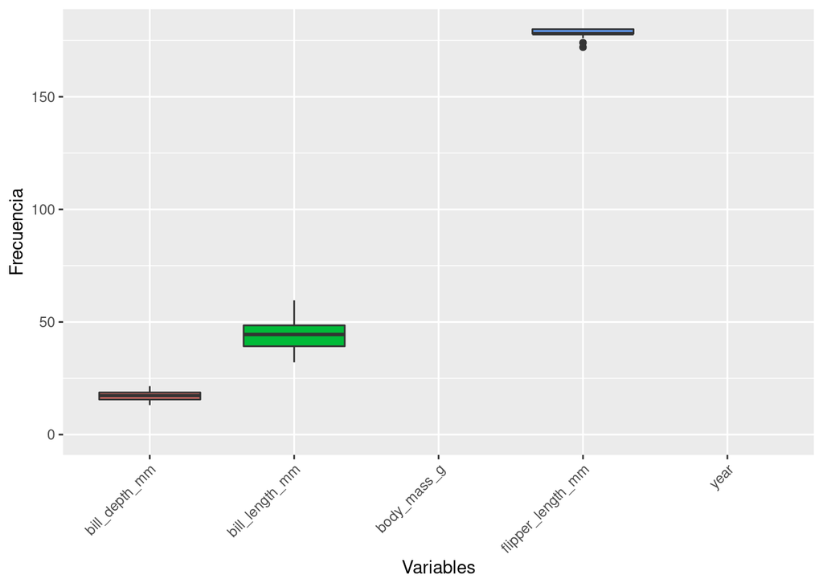

```r
box_plots(dataset)
```

```r
outliers(dataset, column='bill_length_mm')
```

```
## $inf
## [1] 32.1
##
## $sup
## [1] 59.6
```

```r
outliers(dataset, column='bill_length_mm')
```

```
## $inf
## [1] 32.1
##
## $sup
## [1] 59.6
```

```r
outliers(dataset, column='bill_depth_mm')
```

```
## $inf
## [1] 13.1
##
## $sup
## [1] 21.5
```

```r
outliers(dataset, column='flipper_length_mm')
```

```
## $inf
## [1] 172
##
## $sup
## [1] 231
```

```r
outliers(dataset, column='body_mass_g')
```

```
## $inf
## [1] 2700
##
## $sup
## [1] 6300
```

```r
outliers(dataset, column='year')
```

```
## $inf
## [1] 2007
##
## $sup
## [1] 2009
```

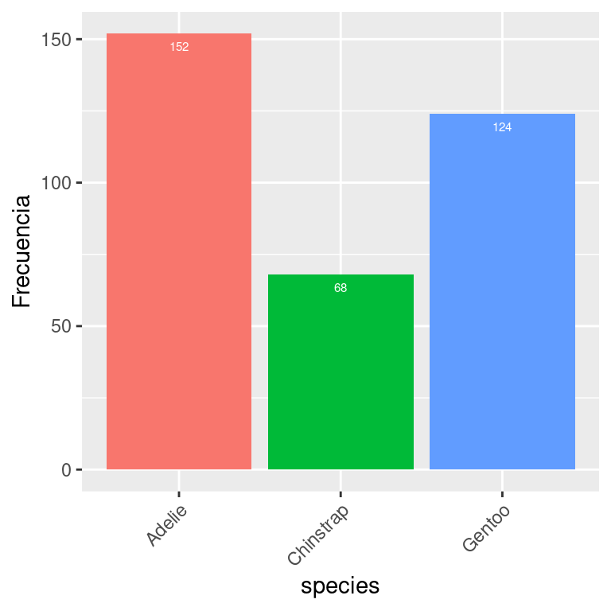

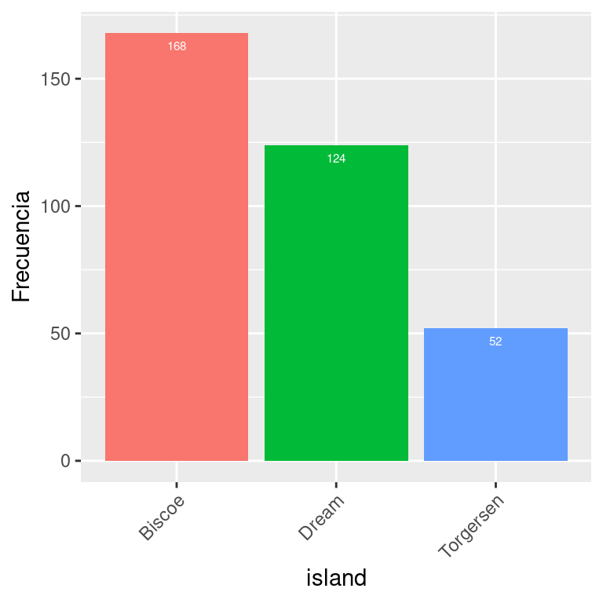

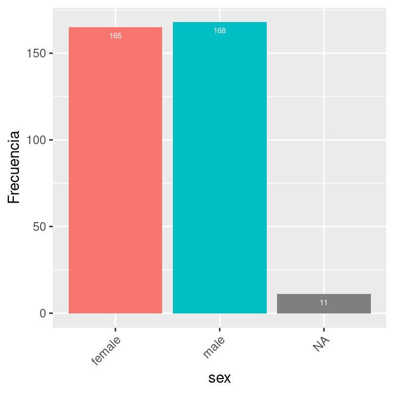

```r
bar_plots(dataset)
```

## 5. Excluir observaciones con missings

```r
dataset <- dataset %>% drop_na()
missings_summary(dataset)
```

| Variable | Nª Categorias | Nª Faltantes | % Faltantes |
| --- | --- | --- | --- |
| sex | 2 | 0 | 0 |
| island | 3 | 0 | 0 |
| species | 3 | 0 | 0 |
| year | 3 | 0 | 0 |
| flipper_length_mm | 54 | 0 | 0 |
| bill_depth_mm | 79 | 0 | 0 |
| body_mass_g | 93 | 0 | 0 |
| bill_length_mm | 163 | 0 | 0 |

## 6. Correlaciones

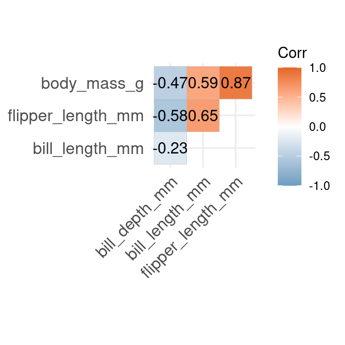

```r
corr_plot(dataset %>% dplyr::select(-year))
```

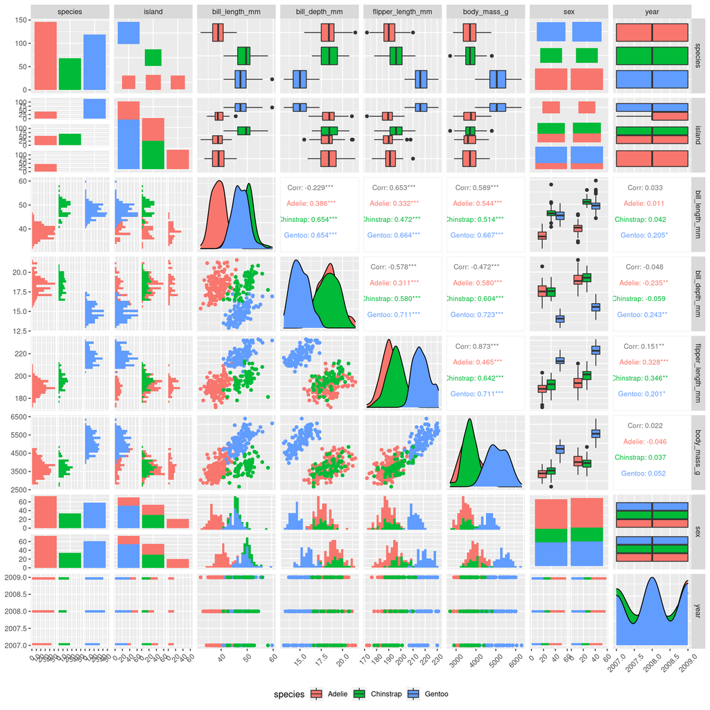

```r
segmented_pairs_plot(dataset, segment_column='species')
```

# Experimentos

## Experimento 1

- Solo variables numéricas
- Regresión múltiple frecuentista.
- regresión múltiple bayesiana con priors normales y exponencial.

### 1. Split train - test

```r
train_test <- train_test_split(dataset, train_size = 0.7, shuffle = TRUE)
```

```
## [1] "Train set size: 233"
## [1] "Test set size: 100"
```

```r
train_set <- train_test[[1]]
test_set  <- train_test[[2]]
```

### 2. Modelo lineal

```r
lineal_model_1 <- lm(
  body_mass_g ~ bill_length_mm + bill_depth_mm + flipper_length_mm,
  data = train_set
)
```

### 3. Modelo bayesiano

```r
bayesion_model_1 <- stan(
  model_code =  "
    data {
      int<lower=1>               obs_count;
      vector<lower=1>[obs_count] x1;
      vector<lower=1>[obs_count] x2;
      vector<lower=1>[obs_count] x3;
      vector[obs_count]          y;
    }
    parameters {
      real          beta0;
      real          beta1;
      real          beta2;
      real          beta3;
      real<lower=0> sigma;
    }
    model {
      beta0 ~ normal(0, 8000);
      beta1 ~ normal(0, 100);
      beta2 ~ normal(0, 100);
      beta3 ~ normal(0, 100);
      sigma ~ exponential(0.1);

      y ~ normal(beta0 + beta1 * x1 + beta2 * x2 + beta3 * x3, sigma);
    }
  ",
  data = list(
      obs_count = nrow(train_set),
      y  = colvalues(train_set, 'body_mass_g'),
      x1 = colvalues(train_set, 'bill_length_mm'),
      x2 = colvalues(train_set, 'bill_depth_mm'),
      x3 = colvalues(train_set, 'flipper_length_mm')
  ),
  chains = 3,
  iter   = 300,
  warmup = 180,
  thin   = 1
)
```

[output not shown]

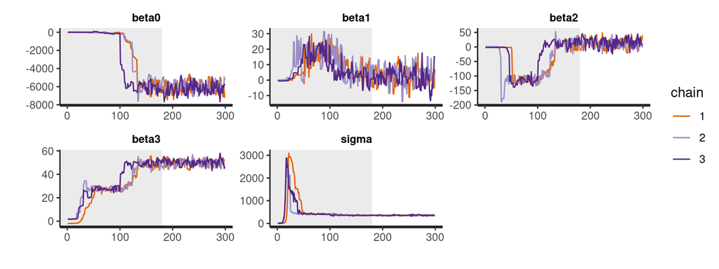

```r
params_1 <- c('beta0', 'beta1', 'beta2', 'beta3', 'sigma')
traceplot(bayesion_model_1, pars = params_1, inc_warmup = TRUE)
```

### 4. Coeficientes

```r
lm_vs_br_coeficients(lineal_model_1, bayesion_model_1, params_1)
```

|  | Regresión Lineal | Regresión Bayesiana |
| --- | --- | --- |
| (Intercept) | -6074.063371 | -6148.751370 |
| bill_length_mm | 3.530265 | 2.367732 |
| bill_depth_mm | 12.534335 | 13.634251 |
| flipper_length_mm | 49.317547 | 49.849930 |

### 4. Validación

```r
vars_1 <- c('bill_length_mm', 'bill_depth_mm', 'flipper_length_mm')

models_validation(lineal_model_1, bayesion_model_1, params_1, vars_1, test_set)
```

| model | rmse | mae |
| --- | --- | --- |
| Bayesian Regression | 417.0364 | 327.0953 |
| Lineal Regression | 417.2990 | 327.8372 |

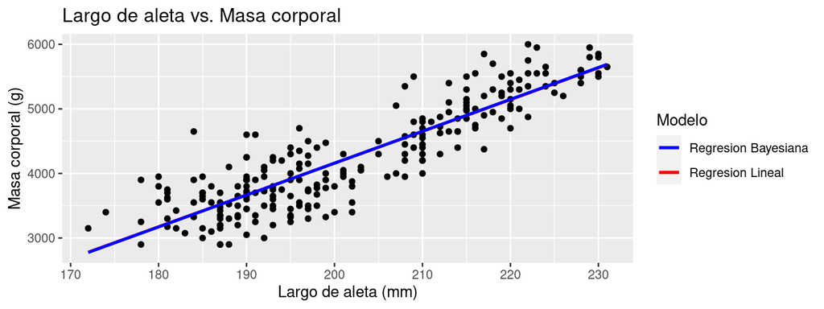

```r
bayesion_predictor_1 <- BayesianRegressionPredictor.from(bayesion_model_1, params_1, vars_1)

plot_compare_fit(
  lineal_model_1,
  bayesion_predictor_1,
  train_set,
  label_1='Regresion Lineal',
  label_2='Regresion Bayesiana'
)
```

## Experimento 2

- Igual al experimento A, incorporar una variable categorica.
- Regresión multiple frecuentista.
- Regresion bayesiana con priors normales y exponencial.

### 1. Modelo lineal

```r
lineal_model_2 <- lm(
    body_mass_g
      ~ bill_length_mm
      + bill_depth_mm
      + flipper_length_mm
      + sex,

  data = train_set
)
```

### 2. Modelo bayesiano

Antes que anda transformamos la columna categórica a un one-hot encoding:

```r
cat_cols      <- c('sex')

train_set_cat <- train_set %>% dummify(cat_cols)
test_set_cat  <- test_set  %>% dummify(cat_cols)

train_set_cat
```

| sex_female | sex_male | species | island | bill_length_mm | bill_depth_mm | flipper_length_mm | body_mass_g | year |
| --- | --- | --- | --- | --- | --- | --- | --- | --- |
| 0 | 1 | Chinstrap | Dream | 52.2 | 18.8 | 197 | 3450 | 2009 |
| 1 | 0 | Gentoo | Biscoe | 45.4 | 14.6 | 211 | 4800 | 2007 |
| 0 | 1 | Adelie | Torgersen | 42.1 | 19.1 | 195 | 4000 | 2008 |
| 0 | 1 | Gentoo | Biscoe | 50.0 | 15.9 | 224 | 5350 | 2009 |
| 0 | 1 | Adelie | Dream | 41.5 | 18.5 | 201 | 4000 | 2009 |
| 0 | 1 | Adelie | Torgersen | 41.5 | 18.3 | 195 | 4300 | 2009 |
| 1 | 0 | Adelie | Biscoe | 34.5 | 18.1 | 187 | 2900 | 2008 |
| 0 | 1 | Adelie | Dream | 37.5 | 18.5 | 199 | 4475 | 2009 |
| 0 | 1 | Chinstrap | Dream | 52.0 | 20.7 | 210 | 4800 | 2008 |
| 1 | 0 | Adelie | Biscoe | 37.9 | 18.6 | 172 | 3150 | 2007 |

[output cut: 223 more lines]

Construimos una matriz con todas las variables x + intercept.

```r
to_model_input <- function(df) {
  model.matrix(
    body_mass_g
      ~ bill_length_mm
      + bill_depth_mm
      + flipper_length_mm
      + sex_female
      + sex_male,

    data = df
  )
}

train_X <- train_set_cat %>% to_model_input()
test_X  <- test_set_cat %>% to_model_input()
```

```r
bayesion_model_2 <- stan(
  model_code = "
    data {
      int<lower=1>                 obs_count;
      int<lower=1>                 coef_count;
      matrix[obs_count,coef_count] X;
      vector[obs_count]            y;
    }
    parameters {
      vector[coef_count]  beta;
      real<lower=0>       sigma;
    }
    model {
      beta[1] ~ normal(0, 2000);

      beta[2] ~ normal(0, 30);
      beta[3] ~ normal(0, 100);
      beta[4] ~ normal(0, 100);

      beta[5] ~ normal(0, 100);
      beta[6] ~ normal(0, 100);

      sigma ~ exponential(0.1);

      y ~ normal(X * beta, sigma);
    }
  ",
  data = list(
      obs_count  = dim(train_X)[1],
      coef_count = dim(train_X)[2],
      y          = colvalues(train_set_cat, 'body_mass_g'),
      X          = train_X
  ),
  chains = 3,
  iter   = 300,
  warmup = 180,
  thin   = 1
)
```

[output not shown]

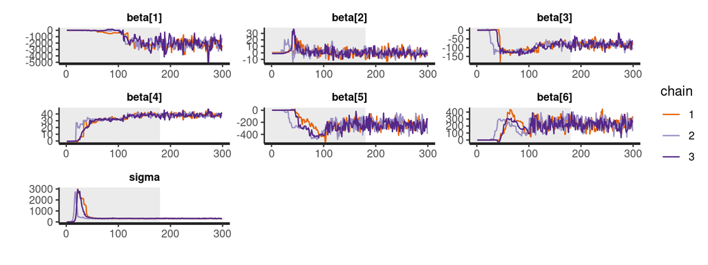

```r
params_2 <- c('beta[1]', 'beta[2]', 'beta[3]', 'beta[4]', 'beta[5]', 'beta[6]', 'sigma')
traceplot(bayesion_model_2, inc_warmup = TRUE, pars = params_2)
```

### 3. Coeficientes

```r
lineal_model_2$coefficients
```

```
##       (Intercept)    bill_length_mm     bill_depth_mm flipper_length_mm
##     -1922.6152066        -0.5330962       -92.9216684        37.2016333
##           sexmale
##       534.1583252
```

```r
br_coeficients(bayesion_model_2, params_2)
```

| Coeficiente | Valor |
| --- | --- |
| beta[1] | -2.122282e+03 |
| beta[2] | -5.955544e-02 |
| beta[3] | -8.112232e+01 |
| beta[4] | 3.842518e+01 |
| beta[5] | -2.325842e+02 |
| beta[6] | 2.329702e+02 |
| sigma | 3.106552e+02 |

### 4. Validación

```r
vars_2 <- c('bill_length_mm', 'bill_depth_mm', 'flipper_length_mm', 'sex_female','sex_male')

models_validation(
  lineal_model_2,
  bayesion_model_2,
  params_2,
  vars_2,
  test_set,
  test_set_cat
)
```

| model | rmse | mae |
| --- | --- | --- |
| Bayesian Regression | 368.5124 | 301.0850 |
| Lineal Regression | 366.6626 | 301.0897 |

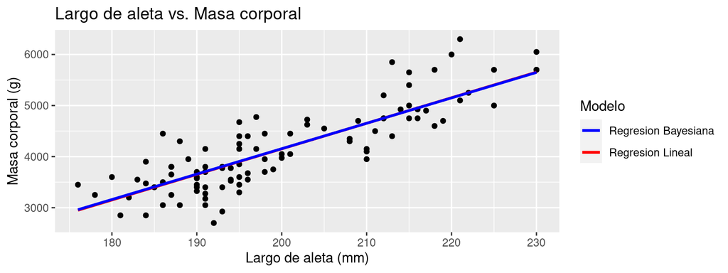

```r
bayesion_predictor_2 <- BayesianRegressionPredictor.from(bayesion_model_2, params_2, vars_2)

plot_compare_fit(
  lineal_model_2,
  bayesion_predictor_2,
  test_set,
  test_set_cat,
  label_1='Regresion Lineal',
  label_2='Regresion Bayesiana'
)
```

## Experimento 3

- Igual al experimento A incorporando outliers en alguna variable numérica.
- Regresión múltiple frecuentista.
- Regresión bayesiana con priors normales y exponencial.

### 1. Outliers

[figure not shown]

```r
plot_data(train_set)
```

[figure not shown]

```r
train_set_with_outliers <- train_set %>%
  mutate(flipper_length_mm = ifelse(
    body_mass_g > 5600 ,
    flipper_length_mm + (flipper_length_mm * runif(1, 0.2, 0.3)),
    flipper_length_mm
  ))

plot_data(train_set_with_outliers)
```

### 2. Modelo lineal

```r
lineal_model_3 <- lm(
  body_mass_g ~ bill_length_mm + bill_depth_mm + flipper_length_mm,
  data = train_set_with_outliers
)
```

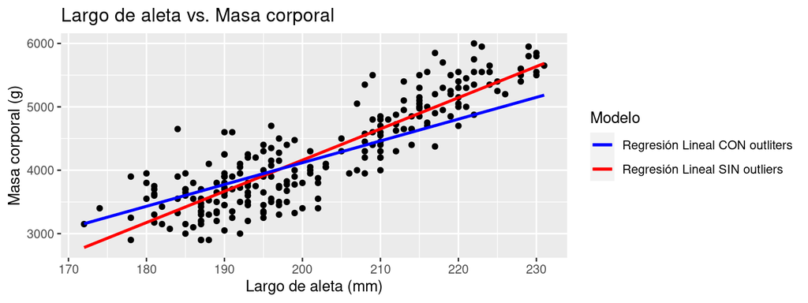

```r
plot_compare_fit(
  lineal_model_1,
  lineal_model_3,
  train_set,
  label_1='Regresión Lineal SIN outliers',
  label_2='Regresión Lineal CON outliters'
)
```

```r
lm_vs_lm_coeficients(lineal_model_1, lineal_model_3)
```

|  | Regresión Lineal A | Regresión Lineal B |
| --- | --- | --- |
| (Intercept) | -6074.063371 | -239.53377 |
| bill_length_mm | 3.530265 | 33.96760 |
| bill_depth_mm | 12.534335 | -67.48299 |
| flipper_length_mm | 49.317547 | 20.21034 |

### 3. Modelo bayesiano

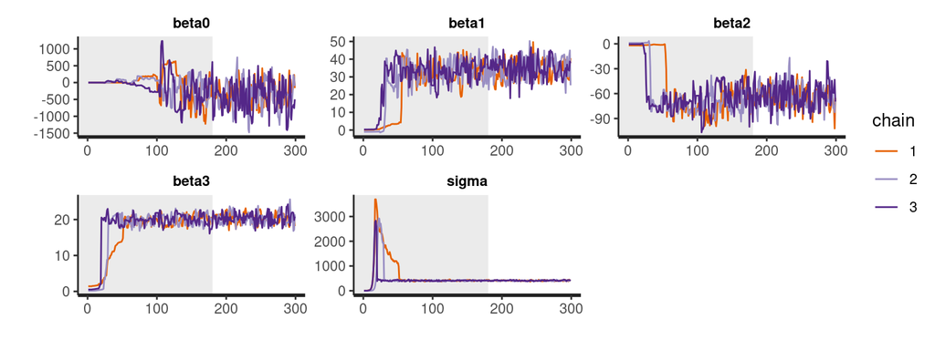

```r
bayesion_model_3 <- stan(
  model_code =  "
    data {
      int<lower=1>               obs_count;
      vector<lower=1>[obs_count] x1;
      vector<lower=1>[obs_count] x2;
      vector<lower=1>[obs_count] x3;
      vector[obs_count]          y;
    }
    parameters {
      real          beta0;
      real          beta1;
      real          beta2;
      real          beta3;
      real<lower=0> sigma;
    }
    model {
      beta0 ~ normal(0, 8000);
      beta1 ~ normal(0, 100);
      beta2 ~ normal(0, 100);
      beta3 ~ normal(0, 100);
      sigma ~ exponential(0.1);

      y ~ normal(beta0 + beta1 * x1 + beta2 * x2 + beta3 * x3, sigma);
    }
  ",
  data = list(
      obs_count = nrow(train_set_with_outliers),
      y  = colvalues(train_set_with_outliers, 'body_mass_g'),
      x1 = colvalues(train_set_with_outliers, 'bill_length_mm'),
      x2 = colvalues(train_set_with_outliers, 'bill_depth_mm'),
      x3 = colvalues(train_set_with_outliers, 'flipper_length_mm')
  ),
  chains = 3,
  iter   = 300,
  warmup = 180,
  thin   = 1
)

params_3 <- c('beta0', 'beta1', 'beta2', 'beta3', 'sigma')
traceplot(bayesion_model_3, pars = params_3, inc_warmup = TRUE)
```

### 4. Coeficientes

```r
lm_vs_br_coeficients(lineal_model_3, bayesion_model_3, params_3)
```

|  | Regresión Lineal | Regresión Bayesiana |
| --- | --- | --- |
| (Intercept) | -239.53377 | -370.69409 |
| bill_length_mm | 33.96760 | 34.49082 |
| bill_depth_mm | -67.48299 | -63.28072 |
| flipper_length_mm | 20.21034 | 20.39533 |

### 5. Validación

```r
vars_3 <- c('bill_length_mm', 'bill_depth_mm', 'flipper_length_mm')

models_validation(lineal_model_3, bayesion_model_3, params_3, vars_3, test_set)
```

| model | rmse | mae |
| --- | --- | --- |
| Bayesian Regression | 508.8858 | 408.0026 |
| Lineal Regression | 509.8461 | 408.9341 |

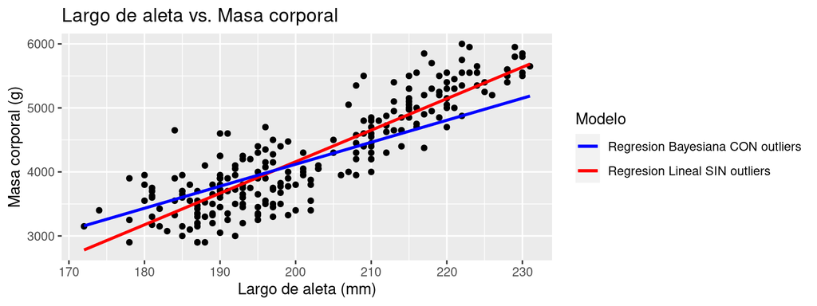

```r
bayesion_predictor_3 <- BayesianRegressionPredictor.from(bayesion_model_3, params_3, vars_3)

plot_compare_fit(
  lineal_model_1,
  bayesion_predictor_3,
  train_set,
  label_1='Regresion Lineal SIN outliers',
  label_2='Regresion Bayesiana CON outliers'
)
```

## Experimento 4

- Idem experimento 1 pero reduciendo la cantidad de observaciones a pocos valores (ej:30).
- Regresion multiple frecuentista.
- Regresion bayesiana con priors normales y exponencial.

### 1. Split train - test

```r
train_test <- train_test_split(dataset, train_size = 0.05, shuffle = TRUE)
```

```
## [1] "Train set size: 16"
## [1] "Test set size: 317"
```

```r
train_set_4 <- train_test[[1]]
test_set_4  <- train_test[[2]]
```

[figure not shown]

```r
plot_data(train_set_4)
```

### 2. Modelo lineal

```r
lineal_model_4 <- lm(
  body_mass_g ~ bill_length_mm + bill_depth_mm + flipper_length_mm,
  data = train_set_4
)
```

### 3. Modelo bayesiano

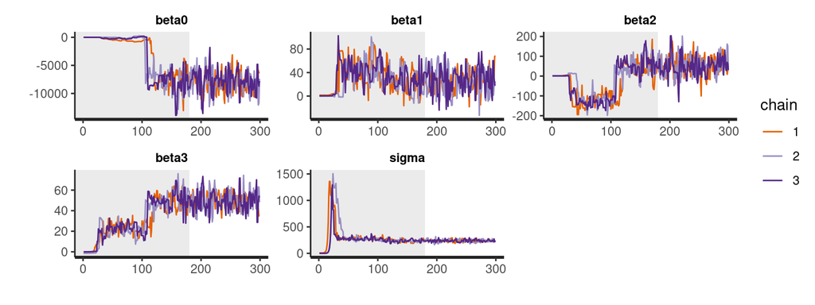

```r
bayesion_model_4 <- stan(
  model_code =  "
    data {
      int<lower=1>               obs_count;
      vector<lower=1>[obs_count] x1;
      vector<lower=1>[obs_count] x2;
      vector<lower=1>[obs_count] x3;
      vector[obs_count]          y;
    }
    parameters {
      real          beta0;
      real          beta1;
      real          beta2;
      real          beta3;
      real<lower=0> sigma;
    }
    model {
      beta0 ~ normal(0, 8000);
      beta1 ~ normal(0, 100);
      beta2 ~ normal(0, 100);
      beta3 ~ normal(0, 100);
      sigma ~ exponential(0.1);

      y ~ normal(beta0 + beta1 * x1 + beta2 * x2 + beta3 * x3, sigma);
    }
  ",
  data = list(
      obs_count = nrow(train_set_4),
      y  = colvalues(train_set_4, 'body_mass_g'),
      x1 = colvalues(train_set_4, 'bill_length_mm'),
      x2 = colvalues(train_set_4, 'bill_depth_mm'),
      x3 = colvalues(train_set_4, 'flipper_length_mm')
  ),
  chains = 3,
  iter   = 300,
  warmup = 180,
  thin   = 1
)

params_4 <- c('beta0', 'beta1', 'beta2', 'beta3', 'sigma')
traceplot(bayesion_model_4, pars = params_4, inc_warmup = TRUE)
```

### 4. Coeficientes

Coeficientes de la regresión múltiple:

```r
lineal_model_4$coefficients
```

```
##       (Intercept)    bill_length_mm     bill_depth_mm flipper_length_mm
##       -8926.26327          24.74177          81.05387          52.87000
```

Coeficientes descubiertos por la regresión múltiple bayesiana:

```r
for(param in params_4) print(get_posterior_mean(bayesion_model_4, par=param)[4])
```

```
## [1] -7895.822
## [1] 26.30672
## [1] 53.77526
## [1] 49.6672
## [1] 236.508
```

### 5. Validación

```r
vars_4 <- c('bill_length_mm', 'bill_depth_mm', 'flipper_length_mm')

models_validation(lineal_model_4, bayesion_model_4, params_4, vars_4, test_set)
```

| model | rmse | mae |
| --- | --- | --- |
| Bayesian Regression | 432.3825 | 339.0269 |
| Lineal Regression | 439.3191 | 345.1538 |

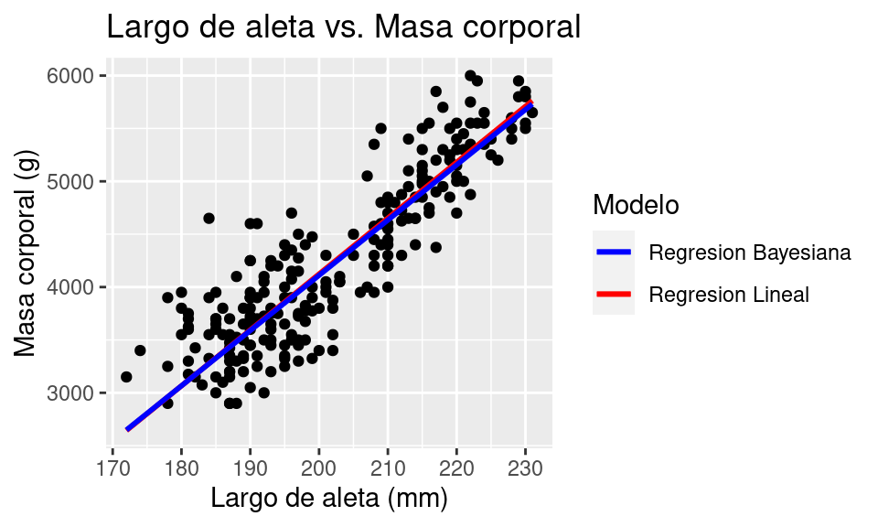

```r
bayesion_predictor_4 <- BayesianRegressionPredictor.from(bayesion_model_4, params_4, vars_4)

plot_compare_fit(
  lineal_model_4,
  bayesion_predictor_4,
  train_set,
  label_1='Regresion Lineal',
  label_2='Regresion Bayesiana'
)
```

## Experimento 5

- Igual al experimento 1 pero proponiendo dos nuevas regresiones bayesianas con priors para los parámetros que sean:
  - Una poca informativa (uniforme).
  - Una muy informativa (sesgada o con muy poca varianza).
- Comparar con resultados de la bayesiana del experimento A

### 1. Modelo bayesiano con parametro con distribucion poco informativa

#### 1. Modelo

[output not shown]

[figure not shown]

#### 2. Coeficientes

```r
br_vs_br_coeficients(bayesion_model_1, bayesion_model_5, params_5)
```

| Coeficiente | Modelo.A | Modelo.B |
| --- | --- | --- |
| beta0 | -6148.751370 | -5957.643012 |
| beta1 | 2.367732 | 4.363462 |
| beta2 | 13.634251 | 10.565939 |
| beta3 | 49.849930 | 48.726540 |
| sigma | 357.475949 | 298.005510 |

#### 3. Validación

```r
models_validation(lineal_model_1, bayesion_model_1, params_1, vars_1, test_set)
```

| model | rmse | mae |
| --- | --- | --- |
| Bayesian Regression | 417.0364 | 327.0953 |
| Lineal Regression | 417.2990 | 327.8372 |

#### 4. Validacion

```r
vars_5 <- c('bill_length_mm', 'bill_depth_mm', 'flipper_length_mm')

models_validation(lineal_model_1, bayesion_model_5, params_5, vars_5, test_set)
```

| model | rmse | mae |
| --- | --- | --- |
| Lineal Regression | 417.2990 | 327.8372 |
| Bayesian Regression | 417.8368 | 328.6437 |

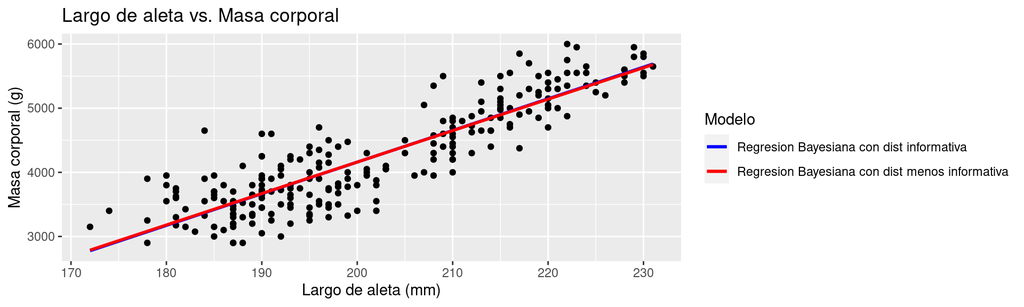

```r
bayesion_predictor_5 <- BayesianRegressionPredictor.from(bayesion_model_5, params_5, vars_5)

plot_compare_fit(
  bayesion_predictor_1,
  bayesion_predictor_5,
  train_set,
  label_1='Regresion Bayesiana con dist informativa',
  label_2='Regresion Bayesiana con dist menos informativa'
)
```